# Make a BGP map Notebook

Eric C. Anderson

## Overview

This chronicles the steps taken whilst making a genoscape for Willow Flycatchers. The order in which we discuss building up this map is different from the order in whic we put layers down to actually make the map. Here, we will start with making the genoscape, which is actually the part that sits atop the whole map. But we do that because that is the part that will actually change from species to species, and we want everyone to be relatively fresh for understanding those mutable parts. Once the genoscape is dealt with, we will then talk about the next layer of country and state boundaries, and also coastline polygons. We do this, because it doesn’t take too long to plot these features, and using them is a good way to figure out the desired extent of your map and to decide upon a projection. Finally, we will talk about the bottom layer of the map, which is the raster with earthforms and shading from Natural Earth Data.

## Packages Needed

### Non-standard Packages

This work draws on a few functions that I have in packages that I have up on GitHub, namely:

1. **my fork** of `tess3r`. Note that you can’t use the default version of `tess3r`, you have to use my fork of it, which has some extra functionality.
2. my package `genoscapeRtools`

Get those packages like this:

```r
remotes::install_github("eriqande/TESS3_encho_sen")  # for special version of tess3r
remotes::install_github("eriqande/genoscapeRtools")  # for Eric's genoscapeRtools
```

### Standard Packages

The rest of the packages you need can be downloaded from CRAN. If you don’t have them you should get them: `raster`, `sf`, `fields`, `downloader`, and `tidyverse`. The last one there gets ggplot2 and a number of other packages by Hadley Wickham.

You can get those like this:

```r
install.packages(c("raster", "sf", "tidyverse", "fields". "downloader"))
```

### Load the Packages We will work with

```r
library(raster)  # important to load before tidyverse, otherwise it masks select()
library(tidyverse)
library(sf)
library(ggspatial)
```

## Making the genoscape

The genoscape are the bright colors smeared across space that show where different genetically identfiable groups of birds reside on the breeding grounds. These genoscapes are stored as rasters, and transparency is used to indicate how much confidence one has in the genetic identification of individuals in different areas. These rasters are made by interpolating Q-values from a program like STRUCTURE or ADMIXTURE between individuals that were sampled in space.

### Input Data

#### Breeding bird Q-values

We need a matrix of Q-values for individuals. We have one that we will read in as a tibble

```r
Q_tibble <- read_table2("inputs/breeding-bird-Q-values.txt")
Q_tibble
```

| id | INW | EST | PNW | SSW | SCC | KER | WMT |
| --- | --- | --- | --- | --- | --- | --- | --- |
| w_WAf001 | 0.004 | 0.002 | 0.987 | 0.001 | 0.002 | 0.003 | 0.001 |
| w_WAf002 | 0.006 | 0.002 | 0.871 | 0.014 | 0.027 | 0.078 | 0.002 |
| w_WAf003 | 0.012 | 0.002 | 0.960 | 0.006 | 0.009 | 0.008 | 0.003 |
| w_WAf004 | 0.006 | 0.002 | 0.962 | 0.006 | 0.016 | 0.005 | 0.002 |
| w_WAf005 | 0.007 | 0.002 | 0.974 | 0.003 | 0.005 | 0.006 | 0.003 |
| w_WAf006 | 0.006 | 0.002 | 0.977 | 0.002 | 0.006 | 0.006 | 0.001 |
| w_WAr001 | 0.005 | 0.002 | 0.970 | 0.005 | 0.013 | 0.004 | 0.001 |
| w_WAr002 | 0.023 | 0.010 | 0.938 | 0.002 | 0.015 | 0.002 | 0.010 |
| w_WAr003 | 0.015 | 0.006 | 0.955 | 0.002 | 0.003 | 0.017 | 0.002 |
| w_WAr004 | 0.010 | 0.002 | 0.977 | 0.002 | 0.003 | 0.004 | 0.001 |

[output cut: 558 more lines]

Column `id` is the sample name and the rest are ancestry fractions to different clusters (named with three characters) estimated by STRUCTURE.

#### Breeding Bird Lat-Longs

We also need to know where those individuals were sampled in space. We have that here:

```r
LatLong_tibble <- read_tsv("inputs/breeding-bird-lat-longs.tsv")
LatLong_tibble
```

| id | Lat | Long |
| --- | --- | --- |
| w_WAf001 | 48.67310 | -122.26000 |
| w_WAf002 | 48.67310 | -122.26000 |
| w_WAf003 | 48.67310 | -122.26000 |
| w_WAf004 | 47.96780 | -124.40000 |
| w_WAf005 | 47.96780 | -124.40000 |
| w_WAf006 | 47.46890 | -121.71000 |
| w_WAr001 | 47.96780 | -124.40050 |
| w_WAr002 | 47.96780 | -124.40050 |
| w_WAr003 | 47.96780 | -124.40050 |
| w_WAr004 | 47.96780 | -124.40050 |

[output cut: 558 more lines]

#### Breeding Bird Cluster Colors

The Q-values correspond to different clusters, as shown above. We must specify the colors that we wish to assign to each of those clusters. We do that with a named vector like this:

```r
cluster_colors <-  c(
  INW = "#984ea3",
  EST = "#377eb8",
  PNW = "#4daf4a",
  SSW = "#ff7f00",
  SCC = "#ffff33",
  KER = "#e41a1c",
  WMT = "#00ffff"
)
```

For fun, we can plot these to see what they look like:

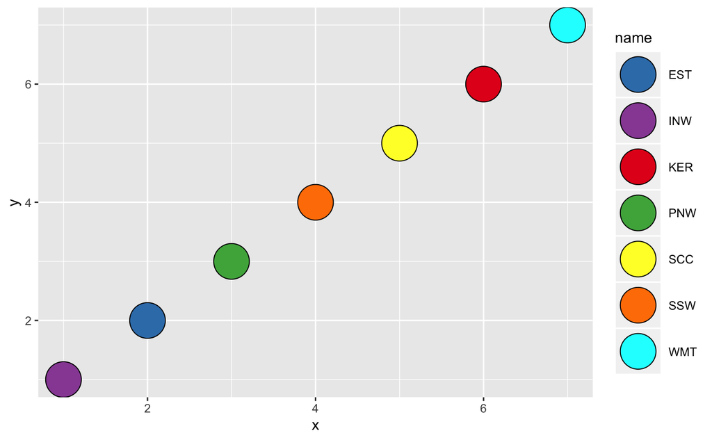

```r
enframe(cluster_colors) %>%
  mutate(x = 1:n(),
         y = 1:n()) %>%
  ggplot(aes(x = x, y = y, fill = name)) +
  geom_point(pch = 21, size = 12) +
  scale_fill_manual(values = cluster_colors)
```

#### Breeding Bird Shapefile

Finally, we need to have a GIS Shapefile that tells us the range of the breeding birds, so that genoscape can be clipped properly. We read this shapefile with the `st_read()` function from package `sf`.

```r
breeding_range <- st_read("inputs/wifl-shapefiles-revised/WIFLrev.shp")
```

For grins, we can plot those polygons to see what they look like:

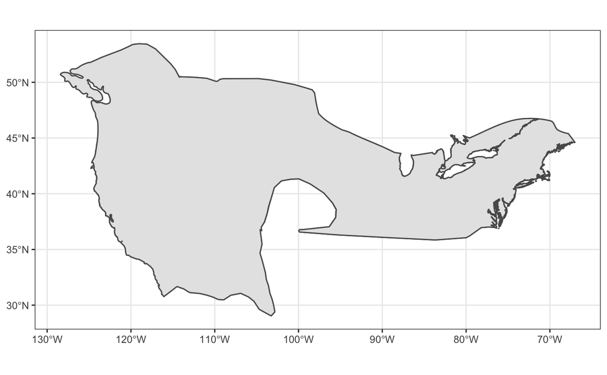

```r
ggplot(breeding_range) +
  geom_sf() +
  theme_bw()
```

### Preparing the data for tess3Q_map_rasters

Within Eric’s fork of `tess3r` is a function called `tess3Q_map_rasters`. It takes input from the objects we have above, but it takes that input as matrices rather than data frames, etc. so there is a little finagling to be done.

#### First, make sure the lat longs are in the correct order and arrangement

We need to ensure that we have values for birds in the right order (a job for a`left_join`), and we also have to make it a matrix with Longitude in the first column and Lat in the second.

```r
long_lat_tibble <- Q_tibble %>%
  select(id) %>%
  left_join(LatLong_tibble, by = "id") %>%
  select(Long, Lat)

long_lat_matrix <- long_lat_tibble %>%
  as.matrix()
```

#### Then, make a matrix of the Q values

Pull off the names of individuals and make a matrix of it:

```r
Q_matrix <- Q_tibble %>%
  select(-id) %>%
  as.matrix()
```

### Interpolate the Q-values by Kriging

For this, we use the above variables in `tess3r::tess3Q_map_rasters()`. Note that use namespace addressing for this function rather than load the `tess3r`

```r
genoscape_brick <- tess3r::tess3Q_map_rasters(
  x = Q_matrix,
  coord = long_lat_matrix,
  map.polygon = breeding_range,
  window = extent(breeding_range)[1:4],
  resolution = c(300,300), # if you want more cells in your raster, set higher
  # this next lines need to to be here, but don't do much...
  col.palette = tess3r::CreatePalette(cluster_colors, length(cluster_colors)),
  method = "map.max",
  interpol = tess3r::FieldsKrigModel(10),
  main = "Ancestry coefficients",
  xlab = "Longitude",
  ylab = "Latitude",
  cex = .4
)

# after that, we need to add names of the clusters back onto this raster brick
names(genoscape_brick) <- names(Q_tibble)[-1]
```

That gives us a raster brick of Q-values associated with each cell in the raster, but those values are not always constrained between 0 and 1, so we have to massage them a little bit in the next section.

### Scaling and cleaning the genoscape_brick

For this we use the function `genoscapeRtools::qprob_rando_raster()`. This sets the colors between clusters to something reasonable and scales things so that the color in each cluster is opaque at the highest value within the clusters, etc. See `?genoscapeRtools::qprob_rando_raster` to learn about the scaling options, etc.

This will squash the raster brick with one element for each cluster down to a single RGBA raster brick.

```r
genoscape_rgba <- genoscapeRtools::qprob_rando_raster(
  TRB = genoscape_brick,
  cols = cluster_colors,
  alpha_scale = 2.0,
  abs_thresh = 0.0,
  alpha_exp = 1.55,
  alpha_chop_max = 230
)

# at this point, we must be explicit about adding a projection to the raster.
# This adds the info for a regular lat-long projection
crs(genoscape_rgba) <- "+proj=longlat +datum=WGS84 +no_defs +ellps=WGS84 +towgs84=0,0,0"
```

We can easily plot this with the function `layer_spatial` from the `ggspatial` package:

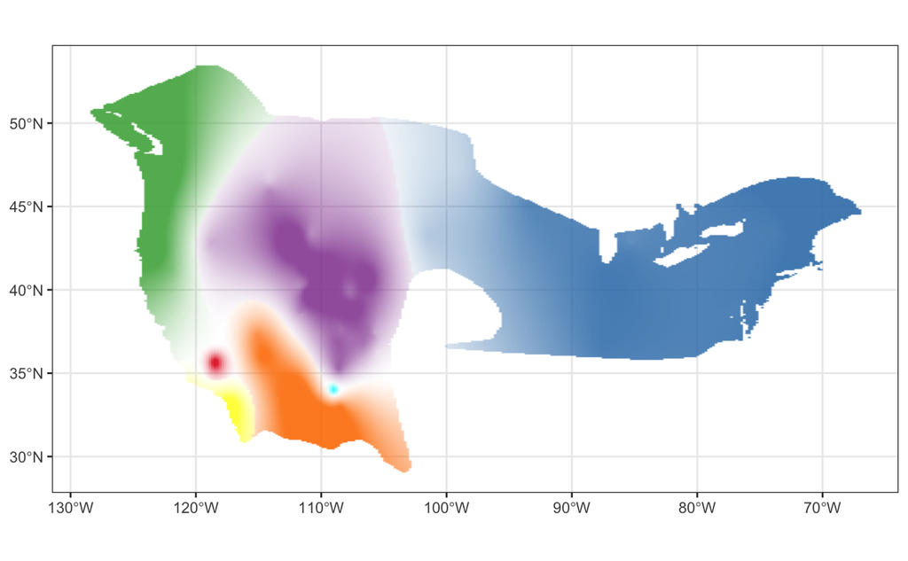

```r
ggplot() +
  ggspatial::layer_spatial(genoscape_rgba) +
  theme_bw() +
  coord_sf()
```

Note that if we wanted to add the actual sampling points to this (that are given in `long_lat_tibble`), we can use ggspatial’s `geom_spatial_point()` function.

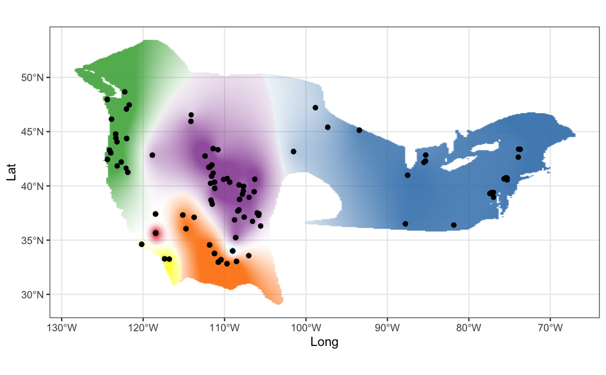

```r
ggplot() +
  layer_spatial(genoscape_rgba) +
  geom_spatial_point(data = long_lat_tibble, mapping = aes(x = Long, y = Lat)) +
  theme_bw() +
  coord_sf()
```

It would probably be better to jigger those points a little bit. That could be done by mutating each of them a random bit away.

## Coastlines, Countries, States, and Provinces

Since we will be using the Natural Earth Data Set for the raster background of our map, we will also use the Natural Earth lines and polygons. The Natural Earth data set is an amazing, open-source resource for making beautiful maps. Check it out at [naturalearthdata.com](https://www.naturalearthdata.com/).

For coastlines, countries, and states/provinces, you will need to download three different shape files. We will be working with the highest resolution Natural Earth data sets which are the `10m` versions. Download and unzip them to a directory within this project called `ne_shapefiles`. You can do that with R like this:

```r
dir.create("ne_shapefiles", showWarnings = FALSE)

tmpfile <- tempfile()
downloader::download(
  url = "https://www.naturalearthdata.com/http//www.naturalearthdata.com/download/10m/physical/ne_10m_coastline.zip",
  dest = tmpfile
)
unzip(zipfile = tmpfile, exdir = "ne_shapefiles")
```

We do the same for country boundaries, and then state/province boundaries, too:

```r
# country boundaries
tmpfile <- tempfile()
downloader::download(
  url = "https://www.naturalearthdata.com/http//www.naturalearthdata.com/download/10m/cultural/ne_10m_admin_0_boundary_lines_land.zip",
  dest = tmpfile
)
unzip(zipfile = tmpfile, exdir = "ne_shapefiles")


# state and province boundaries
# country boundaries
tmpfile <- tempfile()
downloader::download(
  url = "https://www.naturalearthdata.com/http//www.naturalearthdata.com/download/10m/cultural/ne_10m_admin_1_states_provinces.zip",
  dest = tmpfile
)
unzip(zipfile = tmpfile, exdir = "ne_shapefiles")
```

|  | setting | value |
| --- | --- | --- |
| version | version | R version 3.6.1 (2019-07-05) |
| os | os | macOS Sierra 10.12.6 |
| system | system | x86_64, darwin15.6.0 |
| ui | ui | RStudio |
| language | language | (EN) |
| collate | collate | en_US.UTF-8 |
| ctype | ctype | en_US.UTF-8 |
| tz | tz | America/Denver |
| date | date | 2019-11-11 |